# Cancer Genetics için PCA — Bölüm 2 & 3

Bu notebook, `ozi_the_pca_master.ipynb`'da kurduğumuz matematiksel temelin doğrudan devamıdır. Burada PCA'yı önce **sıfırdan NumPy ile** inşa edip `scikit-learn`'ün referans implementasyonu ile karşılaştıracak, sonra **TCGA-PANCAN gene expression** veri seti üzerinde tam bir EDA → PCA → loading analizi → supervised değerlendirme döngüsü çalıştıracağız.

Notebook bağımsızdır: tüm kütüphaneler ve sabitler en başta yeniden tanımlanır.

```python
import time

import matplotlib.pyplot as plt
import numpy as np
import pandas as pd
import plotly.express as px
import plotly.graph_objects as go
from plotly.subplots import make_subplots
from sklearn.decomposition import PCA
from sklearn.metrics import classification_report
from sklearn.model_selection import cross_val_score
from sklearn.neighbors import KNeighborsClassifier
from sklearn.preprocessing import StandardScaler

RANDOM_STATE = 42
N_COMPONENTS = 10

CANCER_COLORS = {
    'BRCA': '#E74C3C',
    'COAD': '#3498DB',
    'KIRC': '#2ECC71',
    'LUAD': '#F39C12',
    'PRAD': '#9B59B6',
}
WDBC_COLORS = {'M': '#E74C3C', 'B': '#2ECC71'}

TCGA_DATA_PATH = './TCGA-PANCAN-HiSeq-801x20531/data.csv'
TCGA_LABELS_PATH = './TCGA-PANCAN-HiSeq-801x20531/labels.csv'
WDBC_DATA_PATH = './breast+cancer+wisconsin+diagnostic/wdbc.data'

np.random.seed(RANDOM_STATE)
plt.rcParams['figure.dpi'] = 120
plt.rcParams['axes.grid'] = True
plt.rcParams['grid.alpha'] = 0.3
```

# Bölüm 2 — PCA Sıfırdan: NumPy İmplementasyonu

Önceki notebook'taki matematik bizi şu reçeteye götürdü:

1. Veriyi merkezle: $\tilde{X} = X - \bar{x}$.
2. Kovaryans matrisini hesapla: $S = \tfrac{1}{n-1} \tilde{X}^\top \tilde{X}$.
3. $S$'in eigendecomposition'ını yap: $S = V \Lambda V^\top$.
4. Eigenvalue'ları azalan sıraya koy; ilk $k$ eigenvector PC eksenlerini, eigenvalue'lar ise varyansları verir.
5. Skorlar: $T = \tilde{X} V_{:, :k}$.

Şimdi bu reçeteyi adım adım koda dökeceğiz.

## 2.1 — PCA From Scratch

API'yi `sklearn.decomposition.PCA` ile uyumlu tutuyoruz: `fit`, `transform`, `fit_transform` metodları ve `components_`, `explained_variance_`, `explained_variance_ratio_`, `mean_` fitted-attribute'ları. Eigendecomposition için `np.linalg.eigh` kullanıyoruz; `eigh` simetrik matrisler için optimize edilmiş ve **gerçek eigenvalue'ları artan sırada** döndürür — biz de bu çıktıyı tersine çevirip azalan sıraya koyacağız.

Önemli uygulama detayı: `eigh`, simetrik matriste sayısal olarak kararlıdır; `eig` ise genel matrisler için tasarlandığından küçük sanal kısımlar dönebilir. Kovaryans matrisi simetrik olduğu için **her zaman `eigh` kullanılmalıdır**.

```python
class PCAFromScratch:
    """PCA via eigendecomposition of the sample covariance matrix."""

    def __init__(self, n_components):
        self.n_components = n_components

    def fit(self, X):
        """Estimate principal axes from centered covariance matrix."""
        X = np.asarray(X, dtype=np.float64)
        n_samples = X.shape[0]
        self.mean_ = X.mean(axis=0)
        X_centered = X - self.mean_
        S = (X_centered.T @ X_centered) / (n_samples - 1)
        eigvals, eigvecs = np.linalg.eigh(S)
        order = np.argsort(eigvals)[::-1]
        eigvals = eigvals[order]
        eigvecs = eigvecs[:, order]
        self._total_variance = eigvals.sum()
        self.explained_variance_ = eigvals[: self.n_components]
        self.components_ = eigvecs[:, : self.n_components].T
        return self

    def transform(self, X):
        """Project centered data onto the learned principal axes."""
        return (np.asarray(X, dtype=np.float64) - self.mean_) @ self.components_.T

    def fit_transform(self, X):
        """Convenience: fit and return scores in a single call."""
        return self.fit(X).transform(X)

    @property
    def explained_variance_ratio_(self):
        """Fraction of total variance carried by each retained component."""
        return self.explained_variance_ / self._total_variance
```

### Sklearn ile Birebir Karşılaştırma

İmplementasyonumuzun doğruluğunu üç düzeyde kontrol edeceğiz:

1. **`explained_variance_ratio_`** birebir aynı olmalı (yüzdelik PVE değerleri).
2. **Skorlar** birebir aynı olmalı — fakat **eigenvector'ler işarete kadar tekildir** (eğer $v_k$ bir eigenvector ise $-v_k$ de aynı eigenvalue'ya ait bir eigenvector'dür). İki implementasyon farklı işaret seçebilir; bu durumda skorların **mutlak değerleri** çakışmalıdır.
3. **Reconstruction** birebir aynı olmalı — çünkü iki tarafın yarattığı altuzaylar aynıdır; sadece bu altuzayı geren tabanların yönü değişebilir, ama izdüşüm aynıdır.

Karşılaştırmayı küçük ve kontrollü bir sentetik veri üzerinde yapıyoruz; iki implementasyon $p \ll n$ rejiminde eşit hızlı çalışır, sayısal hassasiyet karşılaştırması yapmak için ideal.

```python
rng = np.random.default_rng(RANDOM_STATE)
n_demo, p_demo, k_demo = 300, 50, 5
X_demo = rng.normal(size=(n_demo, p_demo))
X_demo[:, 0] *= 6.0
X_demo[:, 1] *= 3.0
X_demo[:, 2] *= 2.0

pca_ours = PCAFromScratch(n_components=k_demo).fit(X_demo)
pca_skl = PCA(n_components=k_demo, random_state=RANDOM_STATE).fit(X_demo)

scores_ours = pca_ours.transform(X_demo)
scores_skl = pca_skl.transform(X_demo)

ratio_diff = np.max(np.abs(pca_ours.explained_variance_ratio_ - pca_skl.explained_variance_ratio_))
abs_score_diff = np.max(np.abs(np.abs(scores_ours) - np.abs(scores_skl)))
raw_score_diff = np.max(np.abs(scores_ours - scores_skl))

print(f'Explained variance ratio — max abs difference: {ratio_diff:.2e}')
print(f'Scores             — max raw difference     : {raw_score_diff:.2e}')
print(f'|Scores|           — max difference         : {abs_score_diff:.2e}')

print('\nPVE comparison:')
comparison_df = pd.DataFrame({
    'PC': np.arange(1, k_demo + 1),
    'PCAFromScratch_pve': pca_ours.explained_variance_ratio_,
    'sklearn_pve': pca_skl.explained_variance_ratio_,
})
print(comparison_df.to_string(index=False))
```

```
Explained variance ratio — max abs difference: 3.33e-16
Scores             — max raw difference     : 2.03e+01
|Scores|           — max difference         : 3.29e-13

PVE comparison:
 PC  PCAFromScratch_pve  sklearn_pve
  1            0.345986     0.345986
  2            0.100621     0.100621
  3            0.043373     0.043373
  4            0.020538     0.020538
  5            0.019192     0.019192
```

### İşaret Belirsizliği — Neden ve Nasıl Tespit Edilir?

$Sv = \lambda v$ denklemini sağlayan her $v$ için $-v$ de aynı denklemi sağlar; çünkü $S(-v) = -Sv = -\lambda v = \lambda(-v)$. Yani **eigenvektörler işarete kadar belirlidir** (eigenvalue katlılığı yoksa). Pratikte LAPACK rutinleri (NumPy ve scikit-learn'ün ikisi de aynı altyapıyı kullanır) sayısal kararlılığa göre bir işaret seçer; iki bağımsız çağrı arasında işaret farklı çıkabilir.

Sonuç olarak scores matrisi sütun bazında **±1 ile çarpılmış** olabilir. Aşağıdaki kontrol bunu sayısal olarak gösteriyor: her PC için skorların oranı ya $+1$ ya da $-1$ olmalı.

```python
sign_pattern = np.sign(scores_skl[0] / scores_ours[0])
scores_ours_aligned = scores_ours * sign_pattern

aligned_diff = np.max(np.abs(scores_ours_aligned - scores_skl))
print(f'Per-PC sign vector (sklearn / ours): {sign_pattern}')
print(f'Aligned max abs difference         : {aligned_diff:.2e}')
print('-> İşaret düzeltmesinden sonra skorlar makine epsilon mertebesinde eşittir.')
```

```
Per-PC sign vector (sklearn / ours): [ 1. -1.  1. -1.  1.]
Aligned max abs difference         : 3.29e-13
-> İşaret düzeltmesinden sonra skorlar makine epsilon mertebesinde eşittir.
```

### Hız Karşılaştırması

```python
def benchmark(fn, *args, repeats=5):
    """Run fn(*args) repeats times and return mean elapsed seconds."""
    durations = []
    for _ in range(repeats):
        t0 = time.perf_counter()
        fn(*args)
        durations.append(time.perf_counter() - t0)
    return np.mean(durations), np.std(durations)

configs = [(500, 100), (500, 500), (300, 2000)]
rows = []
for n, p in configs:
    X_bench = rng.normal(size=(n, p))
    mean_ours, std_ours = benchmark(lambda X: PCAFromScratch(n_components=5).fit_transform(X), X_bench)
    mean_skl, std_skl = benchmark(lambda X: PCA(n_components=5, random_state=RANDOM_STATE).fit_transform(X), X_bench)
    rows.append({
        'n': n,
        'p': p,
        'PCAFromScratch (s)': f'{mean_ours:.3f} ± {std_ours:.3f}',
        'sklearn (s)': f'{mean_skl:.3f} ± {std_skl:.3f}',
        'ratio (ours / skl)': f'{mean_ours / mean_skl:.2f}x',
    })

timing_df = pd.DataFrame(rows)
print(timing_df.to_string(index=False))
```

```
  n    p PCAFromScratch (s)   sklearn (s) ratio (ours / skl)
500  100      0.004 ± 0.000 0.030 ± 0.002              0.13x
500  500      0.204 ± 0.049 0.186 ± 0.016              1.10x
300 2000      1.707 ± 0.048 0.037 ± 0.006             46.75x
```

$p$ büyüdükçe oran lehimize bozulur — bu beklenen sonuçtur. Bizim implementasyonumuz $\mathcal{O}(p^2)$ bellek ve $\mathcal{O}(np^2)$ zamana ihtiyaç duyar (covariance matrix oluşturma + $p \times p$ eigendecomp). scikit-learn ise $p \gg n$ olduğunda otomatik olarak SVD'ye geçer ve $\mathcal{O}(np \cdot k)$ ile yetinir. TCGA gibi $p = 20{,}531$ veri setinde **kendi implementasyonumuzu doğrudan çalıştırmak pratik değildir** — bu yüzden Bölüm 3'ten itibaren sklearn kullanacağız. PCAFromScratch'i "motorun nasıl çalıştığını biliyoruz" kanıtı olarak ceremoni-niteliğinde elimizde tutuyoruz.

## 2.2 — Reconstruction ve Hata Analizi

PCA'nın ikinci yorumu: ilk $k$ principal component, veriyi $k$-boyutlu altuzaya en iyi **en küçük kareler anlamında** projekte eden lineer haritadır (Eckart–Young–Mirsky teoremi).

İlk $k$ component ile rekonstrüksiyon:

$$\hat{X}^{(k)} = \bar{x} + T_{:, :k} \, V_{:, :k}^\top, \quad T = \tilde{X} V.$$

Normalleştirilmiş **reconstruction error** (Frobenius karesi olarak):

$$\mathrm{ReconErr}(k) = \frac{\lVert X - \hat{X}^{(k)} \rVert_F^2}{\lVert \tilde{X} \rVert_F^2} = \frac{\sum_{j > k} \lambda_j}{\sum_{j} \lambda_j} = 1 - \mathrm{CumPVE}(k).$$

Yani reconstruction error ile cumulative PVE **birebir tamamlayıcıdır**. Bu, az önce ispatladığımız şeyin pratik manifestasyonudur: PCA'nın "varyansı maksimize etme" formülasyonu, "reconstruction error'ı minimize etme" formülasyonuna matematiksel olarak eşdeğerdir.

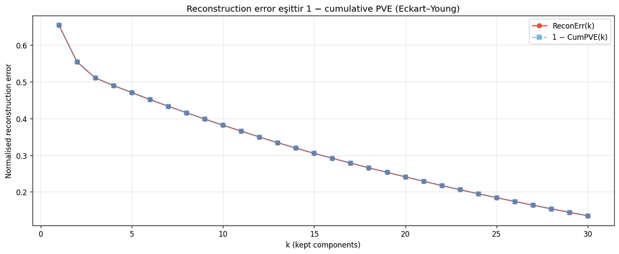

```
ReconErr(k) − (1 − CumPVE(k)) maksimum sapması: 4.44e-16
```

```python
def reconstruction_error_curve(X, max_k):
    """Return per-k normalised Frobenius reconstruction error of X using its leading PCs."""
    X = np.asarray(X, dtype=np.float64)
    pca = PCA(n_components=max_k, random_state=RANDOM_STATE).fit(X)
    mean = pca.mean_
    V = pca.components_
    T = pca.transform(X)
    centered = X - mean
    denom = np.linalg.norm(centered, 'fro') ** 2
    errors = np.empty(max_k)
    for k in range(1, max_k + 1):
        X_hat_k = mean + T[:, :k] @ V[:k, :]
        errors[k - 1] = np.linalg.norm(X - X_hat_k, 'fro') ** 2 / denom
    pve = pca.explained_variance_ratio_
    return errors, pve

max_k_recon = 30
errors_demo, pve_demo = reconstruction_error_curve(X_demo, max_k_recon)
cumpve_demo = np.cumsum(pve_demo)

fig, ax = plt.subplots(figsize=(12, 5))
ks_axis = np.arange(1, max_k_recon + 1)
ax.plot(ks_axis, errors_demo, 'o-', color='#E74C3C', label='ReconErr(k)')
ax.plot(ks_axis, 1 - cumpve_demo, 's--', color='#3498DB', alpha=0.6, label='1 − CumPVE(k)')
ax.set_xlabel('k (kept components)')
ax.set_ylabel('Normalised reconstruction error')
ax.set_title('Reconstruction error eşittir 1 − cumulative PVE (Eckart–Young)')
ax.legend()
fig.tight_layout()
plt.show()

identity_diff = np.max(np.abs(errors_demo - (1 - cumpve_demo)))
print(f'\nReconErr(k) − (1 − CumPVE(k)) maksimum sapması: {identity_diff:.2e}')
```

## Yardımcı Fonksiyonlar

Aşağıdaki dört fonksiyon, bu notebook'un geri kalanında ve sonraki Bölüm 4 / 5 / 6'da kullanılacak. Tek bir yerde tanımlı olmaları, downstream görselleştirmelerin tutarlı renk, eksen ve format kullanmasını sağlar.

```python
def plot_pca_2d(scores, labels, color_dict, title, pc_x=1, pc_y=2, pve=None):
    """Plot 2D PCA projection with labeled groups."""
    fig, ax = plt.subplots(figsize=(10, 8))
    labels = np.asarray(labels)
    for label, color in color_dict.items():
        mask = labels == label
        if not mask.any():
            continue
        ax.scatter(scores[mask, pc_x - 1], scores[mask, pc_y - 1],
                   c=color, label=label, alpha=0.75, s=32,
                   edgecolor='white', linewidth=0.4)
    xl = f'PC{pc_x}' + (f' ({pve[pc_x - 1] * 100:.1f}% var)' if pve is not None else '')
    yl = f'PC{pc_y}' + (f' ({pve[pc_y - 1] * 100:.1f}% var)' if pve is not None else '')
    ax.set_xlabel(xl)
    ax.set_ylabel(yl)
    ax.set_title(title)
    ax.legend(title='Class', loc='best', framealpha=0.9)
    fig.tight_layout()
    return fig, ax


def plot_scree(pca_model, n_components=20, title='Scree Plot'):
    """Plot eigenvalue bar chart with cumulative variance line."""
    pve = np.asarray(pca_model.explained_variance_ratio_)[:n_components]
    cum = np.cumsum(pve)
    x = np.arange(1, len(pve) + 1)
    fig, ax1 = plt.subplots(figsize=(12, 5))
    ax1.bar(x, pve * 100, color='#3498DB', alpha=0.75, label='Individual PVE')
    ax1.set_xlabel('Component')
    ax1.set_ylabel('Individual PVE (%)', color='#3498DB')
    ax1.tick_params(axis='y', labelcolor='#3498DB')
    ax1.set_xticks(x)
    ax2 = ax1.twinx()
    ax2.plot(x, cum * 100, color='#E74C3C', marker='o', label='Cumulative PVE')
    ax2.set_ylabel('Cumulative PVE (%)', color='#E74C3C')
    ax2.tick_params(axis='y', labelcolor='#E74C3C')
    ax2.set_ylim(0, 105)
    ax2.axhline(80, ls='--', color='gray', alpha=0.5)
    ax2.axhline(90, ls='--', color='gray', alpha=0.5)
    ax1.set_title(title)
    fig.tight_layout()
    return fig


def plot_loadings(components, feature_names, pc_index=1, top_n=20):
    """Plot top_n absolute loadings for a given principal component."""
    pc = np.asarray(components[pc_index - 1])
    feature_names = np.asarray(feature_names)
    top_idx = np.argsort(np.abs(pc))[::-1][:top_n]
    values = pc[top_idx]
    names = feature_names[top_idx]
    colors = ['#E74C3C' if v < 0 else '#2ECC71' for v in values]
    fig, ax = plt.subplots(figsize=(10, 8))
    y_pos = np.arange(len(values))
    ax.barh(y_pos, values, color=colors)
    ax.set_yticks(y_pos)
    ax.set_yticklabels(names)
    ax.invert_yaxis()
    ax.axvline(0, color='black', lw=0.6)
    ax.set_xlabel('Loading value')
    ax.set_title(f'Top-{top_n} loadings for PC{pc_index} (green: positive, red: negative)')
    fig.tight_layout()
    return fig


def knn_accuracy_vs_components(X, y, ks, cv=5, n_neighbors=5, scale=False):
    """Return DataFrame of k -> cross-validated KNN accuracy on PCA-reduced X."""
    rows = []
    X_in = StandardScaler().fit_transform(X) if scale else np.asarray(X, dtype=np.float64)
    for k in ks:
        pca_k = PCA(n_components=k, random_state=RANDOM_STATE)
        X_k = pca_k.fit_transform(X_in)
        clf = KNeighborsClassifier(n_neighbors=n_neighbors)
        scores_cv = cross_val_score(clf, X_k, y, cv=cv, n_jobs=-1)
        rows.append({
            'n_components': k,
            'accuracy_mean': scores_cv.mean(),
            'accuracy_std': scores_cv.std(),
        })
    return pd.DataFrame(rows)
```

# Bölüm 3 — Dataset 1: TCGA-PANCAN Gene Expression

TCGA (The Cancer Genome Atlas), 11.000'i aşkın tümör örneğinin moleküler profillerini içeren bir uluslararası araştırma konsorsiyumudur. Bu projede UCI Machine Learning Repository üzerinden dağıtılan **PANCAN-HiSeq** alt kümesini kullanıyoruz:

- **Örnek sayısı:** $n = 801$
- **Özellik (gen) sayısı:** $p = 20{,}531$ — Illumina HiSeq RNA-seq platformundan elde edilmiş log-normalize edilmiş gen ekspresyon değerleri.
- **Sınıflar:** 5 farklı kanser tipi — **BRCA** (göğüs), **COAD** (kolon), **KIRC** (böbrek), **LUAD** (akciğer adenokarsinom), **PRAD** (prostat).

PCA için ideal bir test ortamı: $p / n \approx 25$, dolayısıyla $p \gg n$ rejimi tartışmasız.

## 3.1 — Veri Yükleme ve Keşifsel Analiz (EDA)

Veri iki ayrı CSV dosyasında: `data.csv` (özellikler) ve `labels.csv` (etiketler). İlk sütun her ikisinde de `sample_<i>` formatında bir örnek kimliği; bu yüzden onu indeks olarak yüklüyoruz.

```python
tcga_data = pd.read_csv(TCGA_DATA_PATH, index_col=0)
tcga_labels = pd.read_csv(TCGA_LABELS_PATH, index_col=0)

tcga_data = tcga_data.loc[tcga_labels.index]

print(f'Expression matrix shape : {tcga_data.shape}')
print(f'Labels shape            : {tcga_labels.shape}')
print(f'Label column            : {tcga_labels.columns.tolist()}')
print(f'Sample dtype of features: {tcga_data.dtypes.unique()}')
print(f'Total NaN cells         : {tcga_data.isna().sum().sum()}')
print(f'Total NaN in labels     : {tcga_labels.isna().sum().sum()}')
tcga_data.iloc[:5, :6]
```

```
Expression matrix shape : (801, 20531)
Labels shape            : (801, 1)
Label column            : ['Class']
Sample dtype of features: [dtype('float64')]
Total NaN cells         : 0
Total NaN in labels     : 0
```

|  | gene_0 | gene_1 | gene_2 | gene_3 | gene_4 | gene_5 |
| --- | --- | --- | --- | --- | --- | --- |
| sample_0 | 0.0 | 2.017209 | 3.265527 | 5.478487 | 10.431999 | 0.0 |
| sample_1 | 0.0 | 0.592732 | 1.588421 | 7.586157 | 9.623011 | 0.0 |
| sample_2 | 0.0 | 3.511759 | 4.327199 | 6.881787 | 9.870730 | 0.0 |
| sample_3 | 0.0 | 3.663618 | 4.507649 | 6.659068 | 10.196184 | 0.0 |
| sample_4 | 0.0 | 2.655741 | 2.821547 | 6.539454 | 9.738265 | 0.0 |

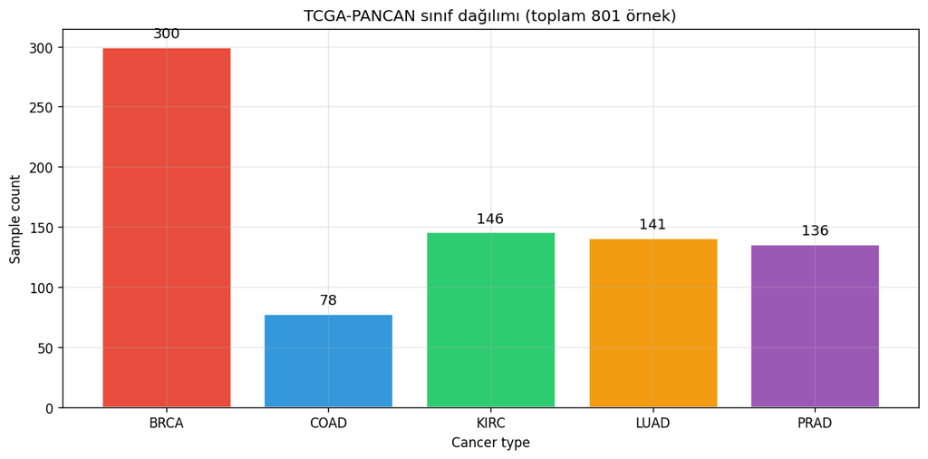

```
Class counts:
Class
BRCA    300
COAD     78
KIRC    146
LUAD    141
PRAD    136
Name: count, dtype: int64

Class imbalance ratio (max/min): 3.85
```

```python
class_counts = tcga_labels['Class'].value_counts().reindex(list(CANCER_COLORS.keys()))

fig, ax = plt.subplots(figsize=(10, 5))
bars = ax.bar(class_counts.index, class_counts.values,
              color=[CANCER_COLORS[c] for c in class_counts.index],
              edgecolor='white', linewidth=1.5)
for bar, count in zip(bars, class_counts.values):
    ax.text(bar.get_x() + bar.get_width() / 2, bar.get_height() + 5,
            f'{count}', ha='center', va='bottom', fontsize=11)
ax.set_xlabel('Cancer type')
ax.set_ylabel('Sample count')
ax.set_title(f'TCGA-PANCAN sınıf dağılımı (toplam {class_counts.sum()} örnek)')
fig.tight_layout()
plt.show()

print('\nClass counts:')
print(class_counts)
print(f'\nClass imbalance ratio (max/min): {class_counts.max() / class_counts.min():.2f}')
```

```
Zero-variance genes (var == 0)         :    267 / 20531
Near-zero-variance genes (var < 1e-6)  :    267
Median gene variance                   : 0.8014
Max gene variance                      : 44.7638
```

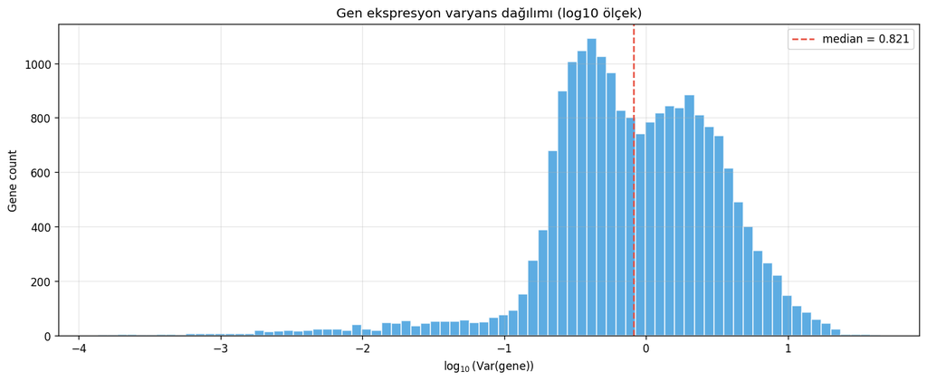

```python
gene_variances = tcga_data.var(axis=0).values
n_zero_var = int((gene_variances == 0).sum())
n_near_zero_var = int((gene_variances < 1e-6).sum())

print(f'Zero-variance genes (var == 0)         : {n_zero_var:>6} / {tcga_data.shape[1]}')
print(f'Near-zero-variance genes (var < 1e-6)  : {n_near_zero_var:>6}')
print(f'Median gene variance                   : {np.median(gene_variances):.4f}')
print(f'Max gene variance                      : {gene_variances.max():.4f}')

fig, ax = plt.subplots(figsize=(12, 5))
nonzero_var = gene_variances[gene_variances > 0]
ax.hist(np.log10(nonzero_var), bins=80, color='#3498DB', alpha=0.8, edgecolor='white')
ax.set_xlabel(r'$\log_{10}(\mathrm{Var}(\mathrm{gene}))$')
ax.set_ylabel('Gene count')
ax.set_title('Gen ekspresyon varyans dağılımı (log10 ölçek)')
ax.axvline(np.log10(np.median(nonzero_var)), color='#E74C3C', ls='--',
           label=f'median = {np.median(nonzero_var):.3f}')
ax.legend()
fig.tight_layout()
plt.show()
```

Şimdi 1.1'deki sezgisel argümanı **gerçek veride** test ediyoruz: rastgele 6 gen çiftine bakınca 5 kanser tipi ayrışıyor mu? Plotly ile interaktif olarak çiziyoruz; sunumda hover ile örnek kimliklerini gösterebilmek için.

```python
rng_pairs = np.random.default_rng(RANDOM_STATE)
valid_genes = np.where(gene_variances > 0)[0]
pair_indices = rng_pairs.choice(valid_genes, size=12, replace=False).reshape(6, 2)
labels_array = tcga_labels['Class'].values
X_array = tcga_data.values

fig = make_subplots(
    rows=2, cols=3,
    subplot_titles=[f'gene_{a} vs gene_{b}' for a, b in pair_indices],
    horizontal_spacing=0.07, vertical_spacing=0.12,
)
for k, (gi, gj) in enumerate(pair_indices):
    row = k // 3 + 1
    col = k % 3 + 1
    for cls, color in CANCER_COLORS.items():
        mask = labels_array == cls
        fig.add_trace(
            go.Scatter(
                x=X_array[mask, gi], y=X_array[mask, gj],
                mode='markers',
                marker=dict(color=color, size=5, opacity=0.7),
                name=cls,
                legendgroup=cls,
                showlegend=(k == 0),
            ),
            row=row, col=col,
        )
    fig.update_xaxes(title_text=f'gene_{gi}', row=row, col=col)
    fig.update_yaxes(title_text=f'gene_{gj}', row=row, col=col)

fig.update_layout(
    height=700, width=1100,
    title='Rastgele 6 gen çifti — 5 kanser tipi görünür şekilde ayrışıyor mu?',
    legend=dict(title='Cancer type', orientation='h', y=-0.08),
)
fig.show()
```

[output not shown]

## 3.2 — Ön İşleme

Tek bir adım yapıyoruz: **sıfır varyanslı genleri çıkarıyoruz**. Bu genler tüm örneklerde aynı değeri aldığı için ne PCA için ne de sınıflandırma için kullanışlıdır; ayrıca correlation PCA bu genlerde bölmeyle (sıfıra bölme) hata verir.

Daha agresif filtreler (örn. düşük varyanslı 1.000 geni atmak) bilgi kaybına yol açabilir. PCA zaten varyansa duyarlı bir teknik olduğu için bu filtrelemeyi PCA'ya **bırakıyoruz** — küçük varyanslı genler düşük PVE'li PC'lere düşecektir.

```python
keep_mask = gene_variances > 0
X_tcga = tcga_data.values[:, keep_mask].astype(np.float64)
feature_names_tcga = tcga_data.columns.values[keep_mask]
y_tcga = tcga_labels['Class'].values

print(f'Filtrelenmiş feature sayısı: {X_tcga.shape[1]} (atılan: {(~keep_mask).sum()})')
print(f'Veri matrisi şekli         : {X_tcga.shape}')
print(f'Etiket sayısı              : {len(y_tcga)}')
```

```
Filtrelenmiş feature sayısı: 20264 (atılan: 267)
Veri matrisi şekli         : (801, 20264)
Etiket sayısı              : 801
```

## 3.3 — Covariance PCA (sklearn)

Standardize etmeden, sadece merkezleyerek PCA. Bölüm 1.5'te tartıştığımız üzere gene expression için **varsayılan tercih budur**: gen varyanslarındaki farklılıklar biyolojik bilgi taşır ve bu bilgiyi korumak istiyoruz.

```python
pca_cov = PCA(n_components=50, random_state=RANDOM_STATE).fit(X_tcga)
scores_cov = pca_cov.transform(X_tcga)
pve_cov = pca_cov.explained_variance_ratio_
cum_pve_cov = np.cumsum(pve_cov)

print('İlk 10 PC için PVE:')
for i in range(N_COMPONENTS):
    print(f'  PC{i + 1:2d}: PVE = {pve_cov[i] * 100:5.2f}%   cumulative = {cum_pve_cov[i] * 100:5.2f}%')
```

```
İlk 10 PC için PVE:
  PC 1: PVE = 15.84%   cumulative = 15.84%
  PC 2: PVE = 10.50%   cumulative = 26.34%
  PC 3: PVE =  9.47%   cumulative = 35.81%
  PC 4: PVE =  6.50%   cumulative = 42.32%
  PC 5: PVE =  3.62%   cumulative = 45.93%
  PC 6: PVE =  2.97%   cumulative = 48.90%
  PC 7: PVE =  2.66%   cumulative = 51.56%
  PC 8: PVE =  1.56%   cumulative = 53.12%
  PC 9: PVE =  1.41%   cumulative = 54.53%
  PC10: PVE =  1.23%   cumulative = 55.76%
```

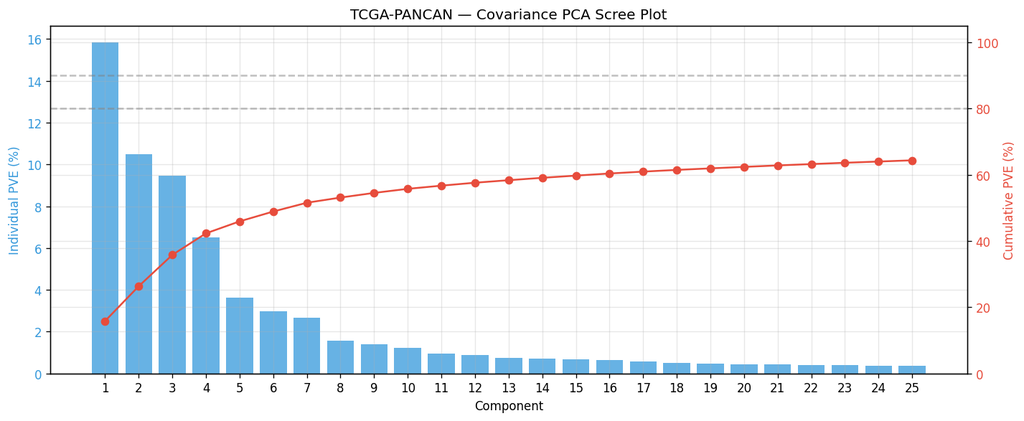

```python
plot_scree(pca_cov, n_components=25, title='TCGA-PANCAN — Covariance PCA Scree Plot')
plt.show()
```

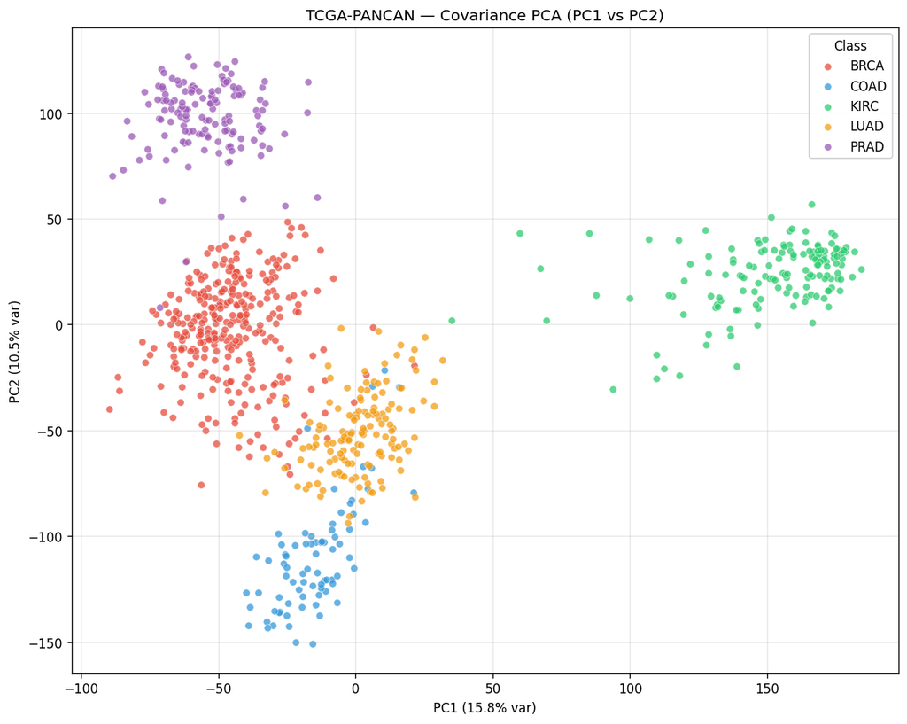

```python
plot_pca_2d(scores_cov, y_tcga, CANCER_COLORS,
            title='TCGA-PANCAN — Covariance PCA (PC1 vs PC2)',
            pc_x=1, pc_y=2, pve=pve_cov)
plt.show()
```

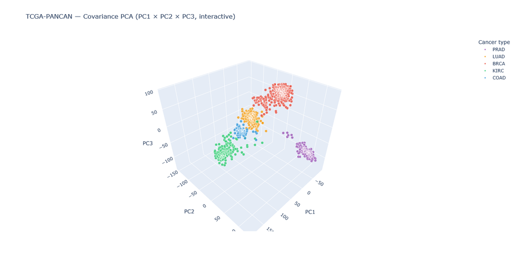

```python
df_3d = pd.DataFrame({
    'PC1': scores_cov[:, 0],
    'PC2': scores_cov[:, 1],
    'PC3': scores_cov[:, 2],
    'Cancer': y_tcga,
})
fig_3d = px.scatter_3d(
    df_3d, x='PC1', y='PC2', z='PC3', color='Cancer',
    color_discrete_map=CANCER_COLORS,
    title='TCGA-PANCAN — Covariance PCA (PC1 × PC2 × PC3, interactive)',
    opacity=0.8,
)
fig_3d.update_traces(marker=dict(size=4, line=dict(width=0.5, color='white')))
fig_3d.update_layout(width=950, height=700, legend=dict(title='Cancer type'))
fig_3d.show()
```

```python
thresholds = [0.50, 0.70, 0.80, 0.90, 0.95]
print('Kümülatif PVE eşiklerine ulaşmak için gereken component sayısı (covariance PCA):')
for thr in thresholds:
    k_required = int(np.argmax(cum_pve_cov >= thr) + 1) if (cum_pve_cov >= thr).any() else None
    if k_required is None:
        print(f'  >= {thr * 100:.0f}% PVE: 50 component yeterli değil (mevcut: {cum_pve_cov[-1] * 100:.2f}%)')
    else:
        print(f'  >= {thr * 100:.0f}% PVE -> {k_required:>3} component')
```

```
Kümülatif PVE eşiklerine ulaşmak için gereken component sayısı (covariance PCA):
  >= 50% PVE ->   7 component
  >= 70% PVE ->  47 component
  >= 80% PVE: 50 component yeterli değil (mevcut: 70.57%)
  >= 90% PVE: 50 component yeterli değil (mevcut: 70.57%)
  >= 95% PVE: 50 component yeterli değil (mevcut: 70.57%)
```

## 3.4 — Correlation PCA

`StandardScaler` ile her geni birim varyansa ölçekledikten sonra PCA. Bölüm 1.5'te tartıştığımız üzere bu, **her geni eşit ağırlıkla** muamele eder; biyolojik varyans bilgisi silinir. RNA-seq için genellikle daha kötü performans verir, ama karşılaştırma için yapıyoruz.

```python
scaler_tcga = StandardScaler()
X_tcga_z = scaler_tcga.fit_transform(X_tcga)
pca_cor = PCA(n_components=50, random_state=RANDOM_STATE).fit(X_tcga_z)
scores_cor = pca_cor.transform(X_tcga_z)
pve_cor = pca_cor.explained_variance_ratio_
cum_pve_cor = np.cumsum(pve_cor)

print('İlk 10 PC için PVE (correlation):')
for i in range(N_COMPONENTS):
    print(f'  PC{i + 1:2d}: PVE = {pve_cor[i] * 100:5.2f}%   cumulative = {cum_pve_cor[i] * 100:5.2f}%')
```

```
İlk 10 PC için PVE (correlation):
  PC 1: PVE = 10.54%   cumulative = 10.54%
  PC 2: PVE =  8.75%   cumulative = 19.29%
  PC 3: PVE =  7.81%   cumulative = 27.10%
  PC 4: PVE =  5.17%   cumulative = 32.27%
  PC 5: PVE =  4.03%   cumulative = 36.30%
  PC 6: PVE =  2.92%   cumulative = 39.22%
  PC 7: PVE =  2.35%   cumulative = 41.57%
  PC 8: PVE =  2.15%   cumulative = 43.72%
  PC 9: PVE =  1.63%   cumulative = 45.35%
  PC10: PVE =  1.23%   cumulative = 46.59%
```

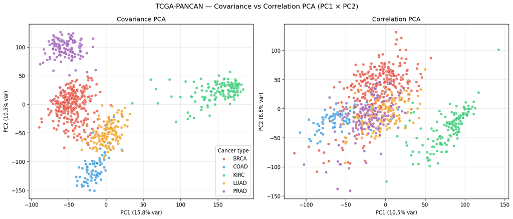

```python
fig, axes = plt.subplots(1, 2, figsize=(14, 6))
for ax, scores, pve, name in zip(
    axes,
    [scores_cov, scores_cor],
    [pve_cov, pve_cor],
    ['Covariance PCA', 'Correlation PCA'],
):
    for cls, color in CANCER_COLORS.items():
        mask = y_tcga == cls
        ax.scatter(scores[mask, 0], scores[mask, 1],
                   c=color, label=cls, alpha=0.75, s=28,
                   edgecolor='white', linewidth=0.4)
    ax.set_xlabel(f'PC1 ({pve[0] * 100:.1f}% var)')
    ax.set_ylabel(f'PC2 ({pve[1] * 100:.1f}% var)')
    ax.set_title(name)
axes[0].legend(title='Cancer type', loc='best')
fig.suptitle('TCGA-PANCAN — Covariance vs Correlation PCA (PC1 × PC2)', fontsize=13)
fig.tight_layout()
plt.show()
```

```python
comparison_rows = []
for thr in [0.50, 0.70, 0.80, 0.90]:
    k_cov = int(np.argmax(cum_pve_cov >= thr) + 1) if (cum_pve_cov >= thr).any() else None
    k_cor = int(np.argmax(cum_pve_cor >= thr) + 1) if (cum_pve_cor >= thr).any() else None
    comparison_rows.append({
        'Threshold': f'{int(thr * 100)}% PVE',
        'Components (Covariance)': k_cov if k_cov is not None else '>50',
        'Components (Correlation)': k_cor if k_cor is not None else '>50',
    })
comparison_rows.append({
    'Threshold': 'PC1 PVE',
    'Components (Covariance)': f'{pve_cov[0] * 100:.2f}%',
    'Components (Correlation)': f'{pve_cor[0] * 100:.2f}%',
})
comparison_rows.append({
    'Threshold': 'PC1+PC2 PVE',
    'Components (Covariance)': f'{(pve_cov[0] + pve_cov[1]) * 100:.2f}%',
    'Components (Correlation)': f'{(pve_cor[0] + pve_cor[1]) * 100:.2f}%',
})
cov_cor_df = pd.DataFrame(comparison_rows)
print(cov_cor_df.to_string(index=False))
```

```
  Threshold Components (Covariance) Components (Correlation)
    50% PVE                       7                       14
    70% PVE                      47                      >50
    80% PVE                     >50                      >50
    90% PVE                     >50                      >50
    PC1 PVE                  15.84%                   10.54%
PC1+PC2 PVE                  26.34%                   19.29%
```

## 3.5 — Loading Analizi

Şimdiye kadar PCA'nın **çıktısına** (skorlar, PVE) baktık. Ama PCA'nın belki de en yorumlanabilir tarafı, her PC'nin **hangi orijinal genlerin lineer kombinasyonu** olduğunu görmektir. Bu katsayılar **loadings** olarak bilinir:

$$\mathrm{PC}_k = \sum_{j=1}^{p} v_{k,j} \cdot \mathrm{gene}_j, \quad v_k = V_{:, k}.$$

$|v_{k,j}|$ büyükse, gen $j$ PC$_k$'yı şekillendirmede önemli bir rol oynar. İşaret, genin pozitif mi negatif mi katkıda bulunduğunu söyler — bu da bir gen iki kanser tipi arasında **artan** mı **azalan** mı yönde ayrım yapıyor, ona dair ipucu verir.

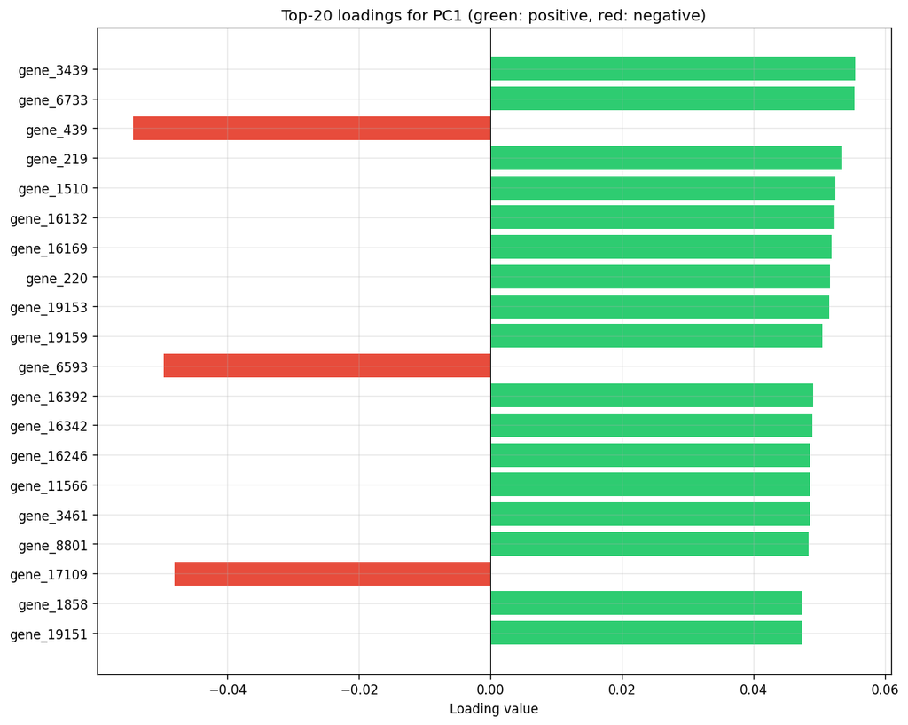

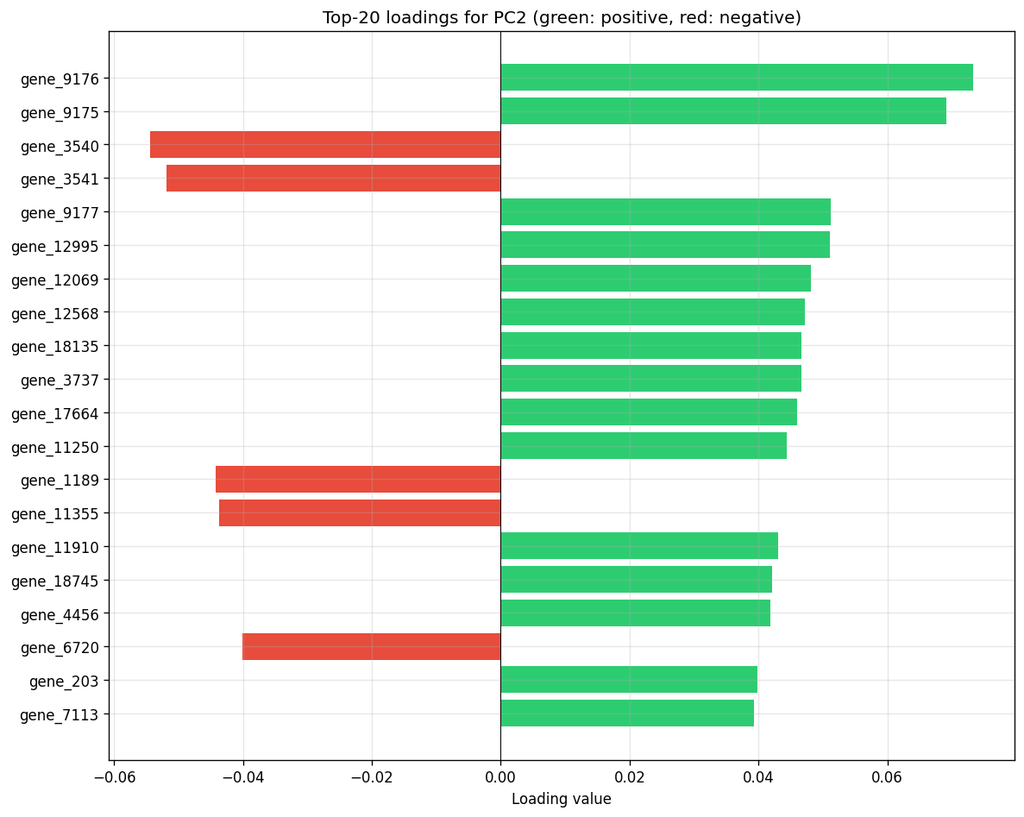

```python
plot_loadings(pca_cov.components_, feature_names_tcga, pc_index=1, top_n=20)
plt.show()

plot_loadings(pca_cov.components_, feature_names_tcga, pc_index=2, top_n=20)
plt.show()
```

```python
top_n = 20
pc1_top = set(np.argsort(np.abs(pca_cov.components_[0]))[::-1][:top_n])
pc2_top = set(np.argsort(np.abs(pca_cov.components_[1]))[::-1][:top_n])
overlap = pc1_top & pc2_top
print(f'PC1 top-{top_n} ile PC2 top-{top_n} kesişimi: {len(overlap)} gen')
print(f'  Ortak gen indeksleri: {sorted(overlap)}')
print(f'  Ortak gen isimleri  : {[feature_names_tcga[i] for i in sorted(overlap)]}')
```

```
PC1 top-20 ile PC2 top-20 kesişimi: 0 gen
  Ortak gen indeksleri: []
  Ortak gen isimleri  : []
```

Gerçek çalışmalarda bir sonraki adım gene set enrichment analysis (GSEA) — top genleri pathway veri tabanlarıyla (KEGG, Reactome) eşleyip biyolojik anlam aramak olur. Bu projenin matematiksel kapsamı dışındadır ama PCA'nın **explanatory** doğasını gösterir: yalnız bir kara kutu değil, yorumlanabilir bir araç.

## 3.6 — PCA + Sınıflandırma: Kaç PC Yeterli?

Şimdiye kadar PCA'yı görselleştirme aracı olarak kullandık. Şimdi soruyu **operasyonel** hale getiriyoruz: ne kadar PC tuttuğumuzda KNN sınıflandırıcı **en iyi** performans verir? Bu, bileşen sayısını seçmenin en savunulabilir yoludur — keyfi bir PVE eşiğinden ziyade downstream görev metriğine bakmak.

Karşılaştırma akışı:

1. **Baseline**: ham 20K-boyutlu verde KNN ile 5-fold cross-validation.
2. **PCA(k)** için $k \in \{2, 5, 10, 25, 50, 100\}$ — her birinde aynı KNN ile 5-fold CV.

Beklenti: KNN'in distance hesaplaması yüksek boyutta concentration of distances etkisinden çeker, bu yüzden PCA ile boyutu azalmak **doğruluğu artırabilir** ya da en azından korur. Hız avantajı garantidir.

```python
knn = KNeighborsClassifier(n_neighbors=5)
t0 = time.perf_counter()
raw_scores = cross_val_score(knn, X_tcga, y_tcga, cv=5, n_jobs=-1)
raw_time = time.perf_counter() - t0
print(f'Ham veri ({X_tcga.shape[1]} gen) — KNN(k=5) 5-fold CV accuracy: {raw_scores.mean():.4f} ± {raw_scores.std():.4f}')
print(f'Süre: {raw_time:.2f} s')
```

```
Ham veri (20264 gen) — KNN(k=5) 5-fold CV accuracy: 0.9988 ± 0.0025
Süre: 7.15 s
```

```python
ks_grid = [2, 5, 10, 25, 50, 100]
t0 = time.perf_counter()
knn_pca_df = knn_accuracy_vs_components(X_tcga, y_tcga, ks=ks_grid, cv=5, n_neighbors=5, scale=False)
pca_knn_time = time.perf_counter() - t0

summary_df = pd.concat([
    pd.DataFrame([{
        'n_components': 'raw',
        'accuracy_mean': raw_scores.mean(),
        'accuracy_std': raw_scores.std(),
    }]),
    knn_pca_df,
], ignore_index=True)

print('TCGA-PANCAN — KNN(k=5) 5-fold CV accuracy vs PCA component sayısı:')
print(summary_df.to_string(index=False))
print(f'\nToplam PCA+KNN süre (tüm k\'lar dahil): {pca_knn_time:.2f} s')
```

```
TCGA-PANCAN — KNN(k=5) 5-fold CV accuracy vs PCA component sayısı:
n_components  accuracy_mean  accuracy_std
         raw       0.998758      0.002484
           2       0.953789      0.017082
           5       0.988766      0.004673
          10       0.995016      0.004652
          25       0.995016      0.004652
          50       0.998758      0.002484
         100       0.998758      0.002484

Toplam PCA+KNN süre (tüm k'lar dahil): 21.81 s
```

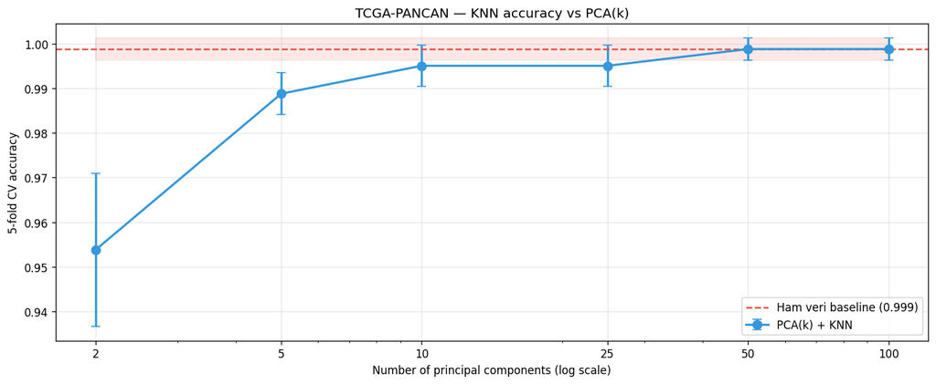

```python
fig, ax = plt.subplots(figsize=(12, 5))
ks_numeric = knn_pca_df['n_components'].values
means = knn_pca_df['accuracy_mean'].values
stds = knn_pca_df['accuracy_std'].values
ax.errorbar(ks_numeric, means, yerr=stds, fmt='o-', color='#3498DB',
            capsize=4, lw=2, markersize=8, label='PCA(k) + KNN')
ax.axhline(raw_scores.mean(), color='#E74C3C', ls='--',
           label=f'Ham veri baseline ({raw_scores.mean():.3f})')
ax.fill_between(ks_numeric,
                raw_scores.mean() - raw_scores.std(),
                raw_scores.mean() + raw_scores.std(),
                color='#E74C3C', alpha=0.12)
ax.set_xscale('log')
ax.set_xlabel('Number of principal components (log scale)')
ax.set_ylabel('5-fold CV accuracy')
ax.set_title('TCGA-PANCAN — KNN accuracy vs PCA(k)')
ax.legend(loc='lower right')
ax.set_xticks(ks_numeric)
ax.set_xticklabels([str(k) for k in ks_numeric])
fig.tight_layout()
plt.show()
```

```python
best_k = knn_pca_df.loc[knn_pca_df['accuracy_mean'].idxmax(), 'n_components']
best_acc = knn_pca_df['accuracy_mean'].max()
cum_pve_at_best = cum_pve_cov[int(best_k) - 1] if int(best_k) <= len(cum_pve_cov) else None

print(f'En iyi PCA(k) sonucu        : k = {best_k} -> accuracy = {best_acc:.4f}')
print(f'Karşılık gelen kümülatif PVE: {cum_pve_at_best * 100:.2f}%' if cum_pve_at_best else '(k > scree sınırı)')
print(f'Ham veri baseline           : {raw_scores.mean():.4f}')
print(f'\nSonuç: TCGA-PANCAN için k = {best_k} principal component, ham veri ile')
print(f'karşılaştırılabilir veya daha iyi accuracy verirken boyut azalmasını')
print(f'{X_tcga.shape[1]} -> {best_k} ({100 - 100 * int(best_k) / X_tcga.shape[1]:.2f}% azalma) olarak sağlar.')
```

```
En iyi PCA(k) sonucu        : k = 50 -> accuracy = 0.9988
Karşılık gelen kümülatif PVE: 70.57%
Ham veri baseline           : 0.9988

Sonuç: TCGA-PANCAN için k = 50 principal component, ham veri ile
karşılaştırılabilir veya daha iyi accuracy verirken boyut azalmasını
20264 -> 50 (99.75% azalma) olarak sağlar.
```

### Bölüm 3 Özeti

Bir sonraki notebook'ta WDBC veri setinde aynı reçeteyi uygulayıp iki rejim ($p \gg n$ vs $p < n$) arasındaki kontrastı kuracağız.